# beatochess no. 13 (October 2025)

Beat Neuenschwander, neuenschwander.beat@gmail.com, https://github.com/beatochess/

I would like to thank Volker Hergert (VH) for contributing significantly to this issue.

I am close to finalizing my “Isenegger project”, which I started in the 1980s. In this issue you find a few “new” studies”, new in the sense that they are not in Harold’s **HHdbVI** database. I found these studies in my personal communications material which I obtained long ago from Paul Mueller-Breil (editor of *Schweizerische Schachzeitung*) and Joseph Maag (editor of the daily Bernise newspaper *Der Bund*).

# New publications

## Seven Chess Notes (June 2025)

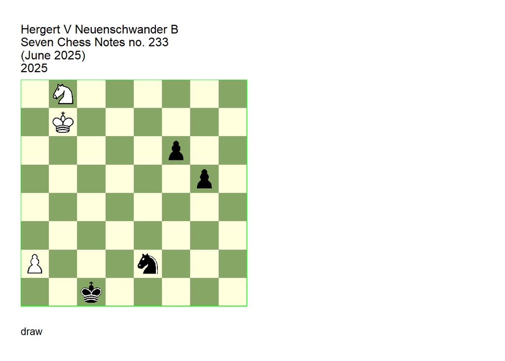

GBR: =0004.12b7c1 FEN: 1N6/1K6/5p2/6p1/8/8/P3n3/2k5 w - - 0 1

**1. a4** (1. Nd7? or 1.Nc6? 1… g4 -+ the g-pawn can’t be stopped and it would be too late to let the a-pawn run. ) **1… Nd4** (1… g4 2. a5 g3 3. a6 g2 4. a7 g1=Q 5. a8=Q!1 would be a trivial draw. Black can instead use a knight fork to try and achieve more. ) **2. a5** (2. Nc6? Nxc6 3. Kxc6 g4 4. a5 g3 5. a6 g2 6. a7 g1=Q 7. a8=Q Qg2+ 8. Kd6 Qxa8 -+) **2… Nb3 3. a6 Nc5+ 4. Kc6** Otherwise, 4…Nxa6 simply wins. **4… Nxa6 5. Nd7!** Now it’s White’s turn to play around with knight forks. (5. Nxa6? g4 6. Nc5 g3 7. Nd3+ Kd2 8. Nf4 Ke3 -+) **5… Nb8+!** The knight insists on sacrificing himself to make his g-pawn hopefully promote. (5… g4 6. Nxf6 g3 7. Nh5 g2 8. Nf4!1) (5… Nb4+ 6. Kd6! (6. Kb5? Nd5 -+) 6… g4 7. Nxf6 g3 8. Nh5 =) **6. Nxb8 g4** At first glance, it might seem that this pawn is unstoppable now - but it will be stopped indeed! **7. Kd5 g3 8. Nc6 g2 9. Nd4** Threatens the same knight fork as in the 5…g5-line. **9… Kd2 10. Ke4 f5+ 11. Kf4!** (11. Kxf5? Ke3 -+) **11… Ke1 12. Nf3+** (12. Kxf5? Kf2 -+) **12… Kf2** After twelve moves from both sides, the re **main** ing stones suddenly and unexpectedly form the letter L. **13. Ng5!** The final knight fork enables the draw. **1/2-1/2**.

## EG no. 242 (October 2025)

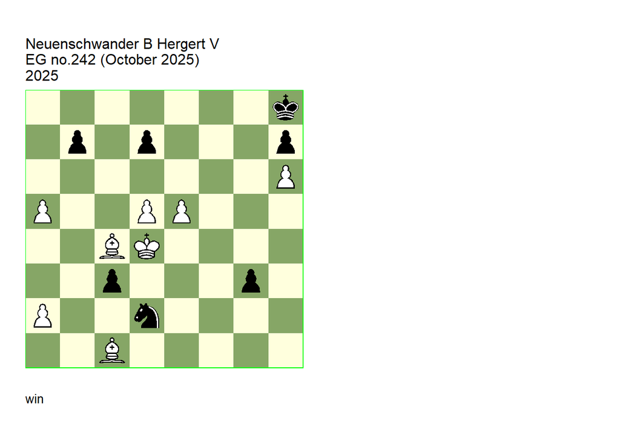

GBR: +0023.55d4h8 FEN: 7k/1p1p3p/7P/P2PP3/2BK4/2p3p1/P2n4/2B5 w - - 0 1

**1. Bf1! Nxf1 2. e6 g2 3. Be3! dxe6 4. d6! Nxe3 5. d7 Nf5+** (5… g1=Q 6. d8=Q+ Qg8 7. Qf6+) **6. Kxc3 g1=Q 7. d8=Q+ Qg8 8. Qf6+ Ng7 9. Kd2!** (9. Kd4? e5+ 10. Kxe5 Qe8+ 11. Kf4 Qa4+) **9… e5 10. Ke1! e4 11. a3! e3 12. a4 e2 13. a6 bxa6 14. a5 1-0**.

# beatochess-12 (updates)

## Caputo +3101.24h7g5 (1987). Changed solution (VH)

Volker pointed out that the study can be saved by changing the solution.

Date: October 08, 2025

File: Caputto1987b.pgn

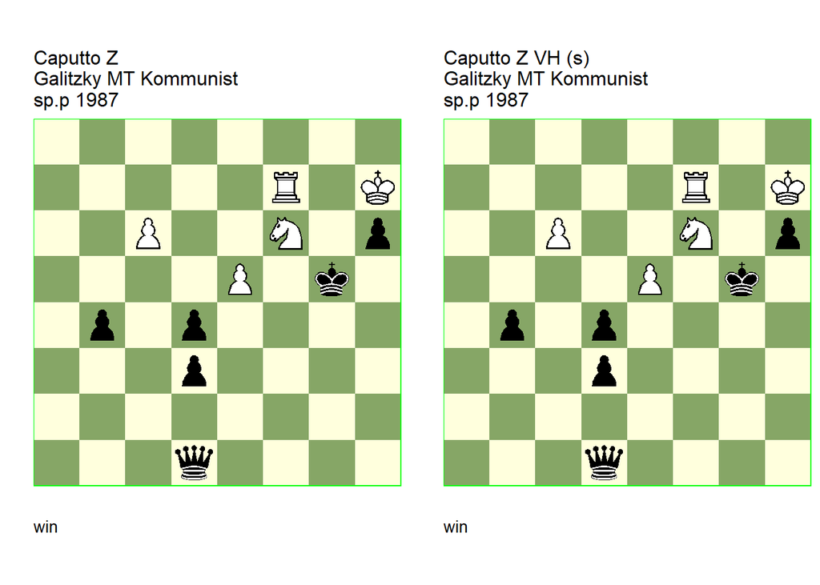

GBR: +3101.24h7g5 U2 FEN: 8/5R1K/2P2N1p/4P1k1/1p1p4/3p4/8/3q4 w - - 0 1

also Probleemblad#066 Probleemblad/3 1988 (EG#07136). U2: Neuenschwander=B beatochess 0/06/2025. **1. Ne4+ Kh5 2. Rf5+** (2. e6! **cook** **BN** 2… Qc2 3. e7 Qxc6 4. e8=Q) **2… Kh4 3. Rf4+ Kh5 4. Rg4 Qxg4 5. Nf6+ Kh4 6. Nxg4 b3 7. Nh2 b2 8. Nf3+ Kg3 9. Nd2 Kf2 10. c7 Ke1 11. c8=Q Kxd2 12. e6 b1=Q 13. e7 1-0**.

GBR: +3101.24h7g5 (s) FEN: 8/5R1K/2P2N1p/4P1k1/1p1p4/3p4/8/3q4 w - - 0 1

changed solution: Hergert=V 08/10/2025. **1. Ne4+! Kh4** (1… Kh5 2. Rf5+ (2. e6! or ) 2… Kh4 3. Rf4+ etc. ) **2. Rf4+ Kh5 3. Rg4!** (3. Rf5+ Kh4 4. Rf4+ Kh5 5. Rg4 waste of time ) **3… Qxg4 4. Nf6+ Kh4 5. Nxg4 b3 6. Nh2! b2 7. Nf3+ Kg3 8. Nd2 1-0**.

## Bazlov +0174.01g5d1 (1979). Cook confirmed (VH)

Volker confirmed (with the help of tablebase) the cook found by Harold. That is, my claim that **2… Nf3+** draws is incorrect.

Date: October 07, 2025

File: Bazlov1979b.pgn

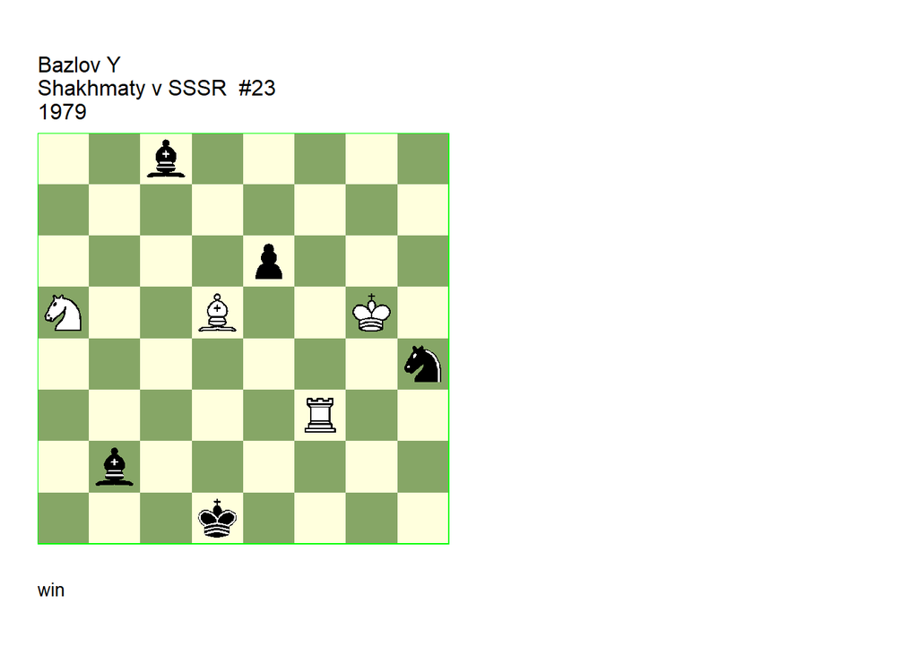

GBR: +0174.01g5d1 (c) U1 FEN: 2b5/8/4p3/N2B2K1/7n/5R2/1b6/3k4 w - - 0 1

Shakhmaty v SSSR/6 21/23.p USSR overall champ XV 1979-1980 64 Shakhmatnoye Obozrenye=20(691) 64 Shakhmatnoye Obozrenye/10 1983. U1: Van, der, Heijden=H HHdbVI 13-11-2018. Comments: Neuenschwander=B beatochess 26/08/2025, Hergert=V 07/10/2025. **1. Rf1+** (1. Bb3+! **cook** HH 1… Ke2 2. Rf8 Bd7 (2… Nf3+! = draw? **BN** 3. Kg4 no! VH 3… Ne5+ 4. Kg3 Bc3 5. Rxc8 Bxa5 6. Bxe6 +- TB win with DTZ 147 ) 3. Kxh4) **1… Kd2 2. Rf2+ Kc3 3. Be4 Nf5 4. Rc2+ Kb4 5. Bxf5 exf5 6. Nb7 Bc3 7. Nc5! Kc4 8. Rc1 Kd4 9. Kh4 f4 10. Na4 1-0**.

# Studies by Samuel Isenegger (part 1)

## Studies not in HHdbVI

### Isenegger =0100.65b1e2 (1941). Cook, correction

File: Isenegger1941a.pgn

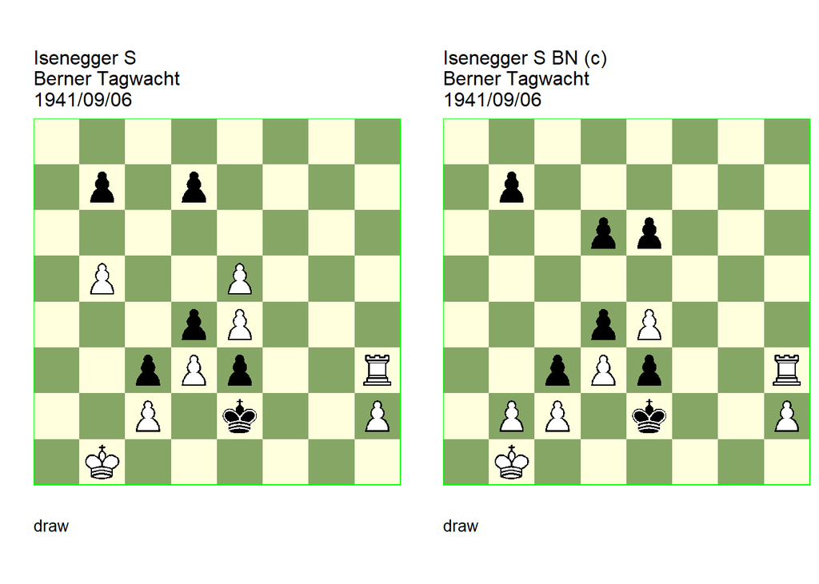

GBR: =0100.65b1e2 U4 U3 -HHdbVI FEN: 8/1p1p4/8/1P2P3/3pP3/2pPp2R/2P1k2P/1K6 w - - 0 1

U4 U3: Neuenschwander=B beatochess 01/10/2025. **1. Rh8!** (1. e6! **cook** **BN** 1… dxe6 2. e5 Kf1 3. Rh4 +-) **1… Kf2 2. Rf8+ Kg2 3. Rg8+ Kh1! 4. Ra8 e2 5. Ra1 e1=Q+ 6. Ka2 Qxa1+ 7. Kxa1 Kxh2 8. Ka2 Kg3 9. Kb3 Kf4 10. Kc4 Ke3 11. Kd5 Kd2 12. Kd6 Kxc2 13. Kxd7 Kxd3 14. e6 c2 15. e7 c1=Q 16. e8=Q** After 16… Kc2 Black is cleary much better **1/2-1/2**.

GBR: =0100.56b1e2 (c) FEN: 8/1p6/3pp3/8/3pP3/2pPp2R/1PP1k2P/1K6 w - - 0 1

correction: Neuenschwander=B beatochess 01/10/2025. **1. Rh8! Kf2 2. Rf8+ Kg2 3. Rg8+ Kh1 4. Ra8! e2 5. Ra1! e1=Q+ 6. Ka2 Qxa1+ 7. Kxa1 cxb2+** (7… Kxh2 8. bxc3 dxc3 9. Ka2) **8. Kxb2 Kxh2 9. Kb3 Kg3 10. Kc4 Kf4 11. Kxd4 1/2-1/2**.

### Isenegger =0047.01b1h5 (1943)

The source of the study is unknown.

File: Isenegger1943a.pgn

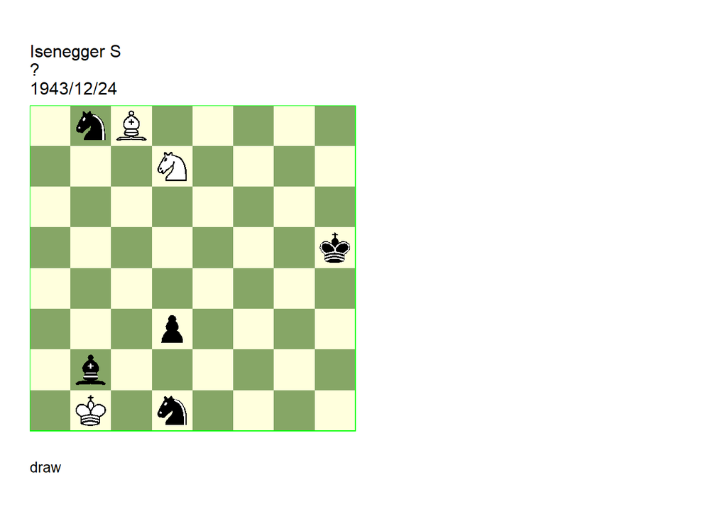

GBR: =0047.01b1h5 -HHdbVI FEN: 1nB5/3N4/8/7k/8/3p4/1b6/1K1n4 w - - 0 1

**1. Nc5 Nc3+ 2. Kxb2 d2 3. Ne4! d1=Q** (3… Nxe4 4. Kc2) **4. Bg4+ Qxg4** (4… Kxg4 5. Nf2+) **5. Nf6+ 1/2-1/2**.

### Isenegger +0612.10g2e2 (1944). Cook, corrections (BN, VH)

The source of the study is unknown.

Volker and I found two corrections independently.

File: Isenegger1944a.pgn

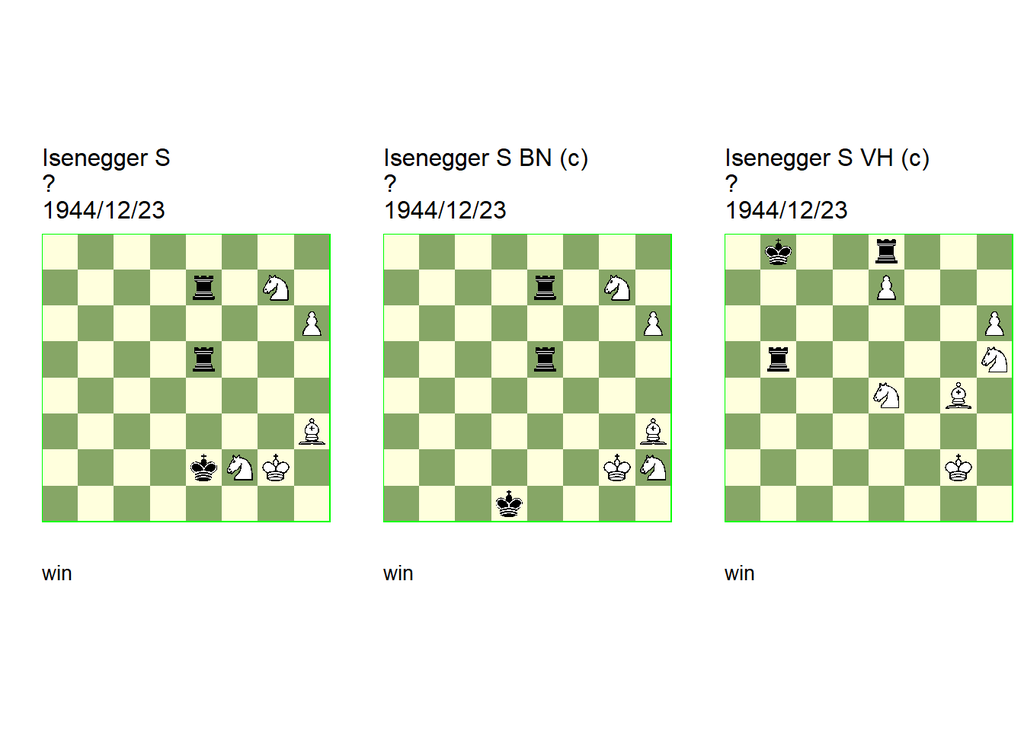

GBR: +0612.10g2e2 U2 -HHdbVI FEN: 8/4r1N1/7P/4r3/8/7B/4kNK1/8 w - - 0 1

U2: Neuenschwander=B beatochess 03/10/2025. **1. Bg4+ Kd2 2. h7 Rh5! 3. Bxh5** (3. Ne4+ ! **cook** **BN** ) **3… Rxg7+ 4. Bg6! Rxg6+ 5. Ng4! Rxg4+ 6. Kh3 Rg1 7. Kh2 1-0**.

GBR: +0612.10g2d1 (c) FEN: 8/4r1N1/7P/4r3/8/7B/6KN/3k4 w - - 0 1

correction: Neuenschwander=B beatochess 03/10/2025. **1. Bg4+ Kc1 2. h7 Rh5! 3. Bxh5 Rxg7+ 4. Bg6! Rxg6+ 5. Ng4! Rxg4+ 6. Kh3 Rg1 7. Kh2 1-0**.

GBR: +0612.20g2b8 (c) FEN: 1k2r3/4P3/7P/1r5N/4N1B1/8/6K1/8 w - - 0 1

correction: Hergert=V beatochess 30/10/2025. **1. Ng7! Rxe7 2. h7 Rh5! 3. Bxh5** (3. Nxh5? Rxh7!1) **3… Rxg7+ 4. Ng5!** (4. Ng3? Rxh7!1) **4… Rxg5+ 5. Bg4! Rxg4+ 6. Kh3 1-0**.

### Isenegger +0404.26h4e1 (1944). Cook

File: Isenegger1944c.pgn

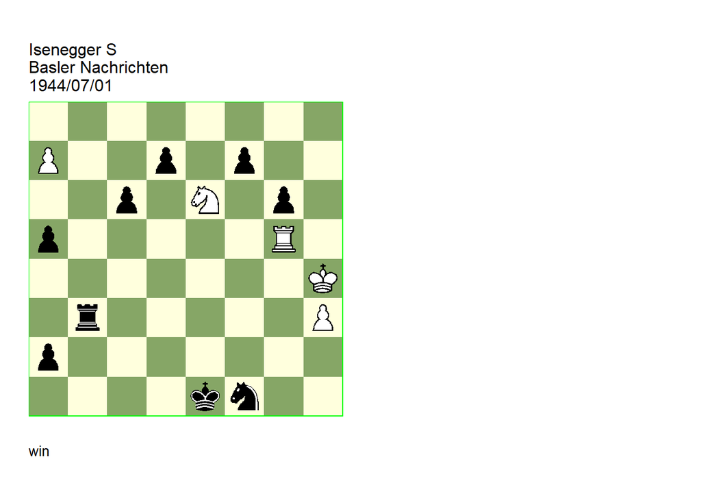

GBR: +0404.26h4e1 U3 -HHdbVI FEN: 8/P2p1p2/2p1N1p1/p5R1/7K/1r5P/p7/4kn2 w - - 0 1

U3: Neuenschwander=B beatochess 17/10/2025. **1. Re5+ Kd1** (1… Kf2! **cook** **BN** ) **2. Rxa5 Rb4+ 3. Nf4! Rxf4+ 4. Kg5 1-0**.

### Isenegger =0000.22g2a4 (1948)

The source of the study is unknown.

File: Isenegger1948d.pgn

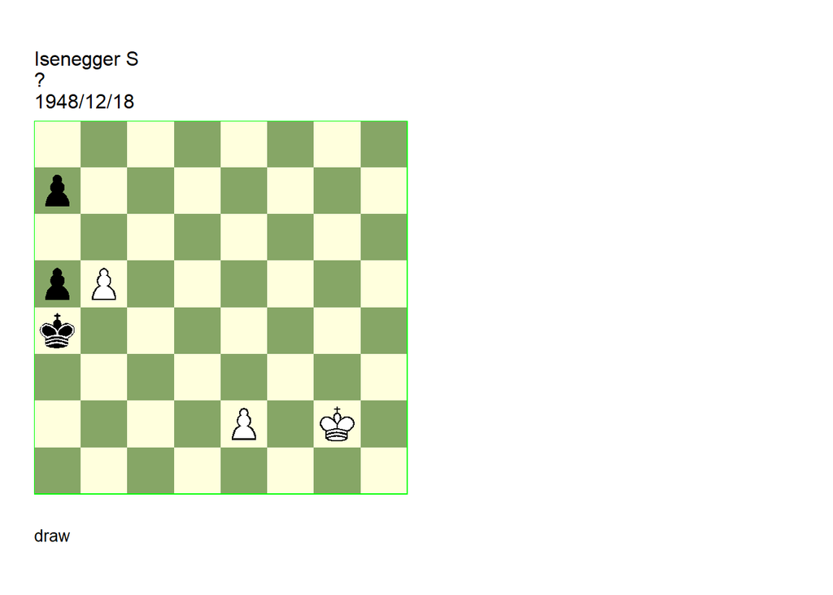

GBR: =0000.22g2a4 -HHdbVI FEN: 8/p7/8/pP6/k7/8/4P1K1/8 w - - 0 1

**1. Kf2!** (1. Kf3? Kb4! -+) (1. Kf1? Kb3! -+) **1… Kb4** (1… Kb3 2. e4 =) (1… Kxb5 2. Ke1 =) **2. Ke1! Kc3 3. Kd1 Kb2 4. e4 a4 5. e5 a3 6. e6 a2 7. e7 a1=Q+ 8. Ke2 1/2-1/2**.

### Isenegger +0400.32h2h4 (1948). Cook, version.

Volker’s version corrects the study, which is now a miniature and has a second mainline–quite remarkable!

File: Isenegger1948e.pgn

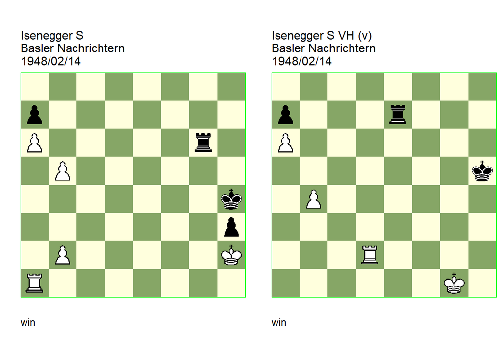

GBR: +0400.32h2h4 U3 -HHdbVI FEN: 8/p7/P5r1/1P6/7k/7p/1P5K/R7 w - - 0 1

U3: Neuenschwander=B beatochess 17/10/2025. **1. Ra4+ Kh5 2. Rd4 Rg2+ 3. Kxh3 Rxb2 4. Rd5+ Kg6 5. Rd6+ Kf5** (5… Kf7 = **cook** **BN** ) (5… Kg7 =) **6. b6 axb6 7. Rd5+ Ke4 8. Ra5! bxa5 9. a7 1-0**.

GBR: +0400.21g1h5 (v) FEN: 8/p3r3/P7/7k/1P6/8/3R4/6K1 w - - 0 1

version: Hergert=V beatochess 30/10/2025. **1. b5!** (1. Kf2? Re4 2. b5 Rb4 3. Rd5+ Kg6 4. Ke3 Kf6!1) **1… Re1+** (1… Re5 2. b6! axb6 3. Ra2 +-) **2. Kf2 Rb1 3. Rd5+!** (3. b6? Rxb6!1) **3… Kg6 4. Rd6+!** (4. Ke3? Kf6!1) **4… Kf5** (4… Kf7 **main** 5. Rd7+ Ke6 (5… Kf6 6. Rb7!) 6. Rxa7 Rxb5 (6… Kd6 7. Rb7 +-) 7. Ra8 Rf5+ (7… Ra5 8. a7 Kf7 9. Rh8! Rxa7 10. Rh7+ Kg6 11. Rxa7 +-) 8. Ke3! (8. Ke2? Rf7!1) (8. Ke1? Rf7!1) 8… Rf7 9. Kd4! (9. Kd3? Kd5 10. a7 Rd7 11. Kc3 Rc7+ 12. Kb4 Kc6!1) 9… Kd6 10. a7 Rd7 11. Kc4! Rc7+ 12. Kb5 +-) **5. b6! axb6 6. Rd5+ Ke4** (6… Ke6 7. Ra5! bxa5 8. a7 +-) **7. Ra5! bxa5 8. a7 1-0**.

### Isenegger +3110.21b1a4 (1951)

File: Isenegger1951a.pgn

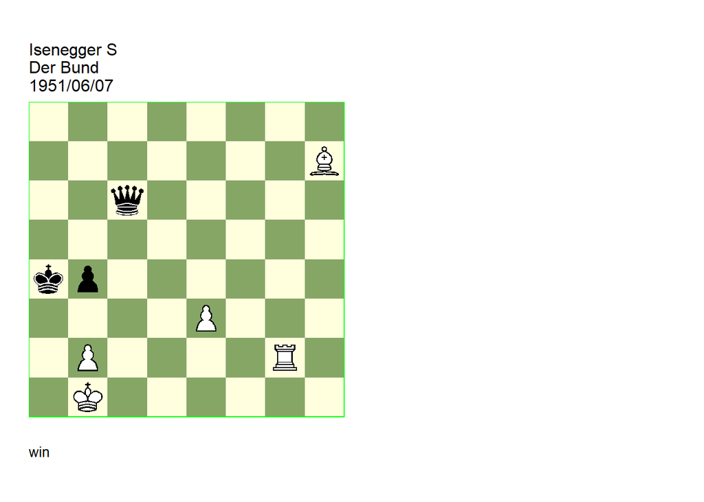

GBR: +3110.21b1a4 -HHdbVI FEN: 8/7B/2q5/8/kp6/4P3/1P4R1/1K6 w - - 0 1

**1. b3+ Kxb3** (1… Ka5 2. Rg5+ Kb6 3. Rg6) **2. Rb2+ Ka4 3. Ra2+ Kb5** (3… Kb3 4. Bg8+) **4. Bd3+ Kb6** (4… Kc5 5. Rc2+ (5. Ra5+) ) **5. Ra6+ 1-0**.

### Isenegger =0001.06a1a3 (1951)

File: Isenegger1951b.pgn

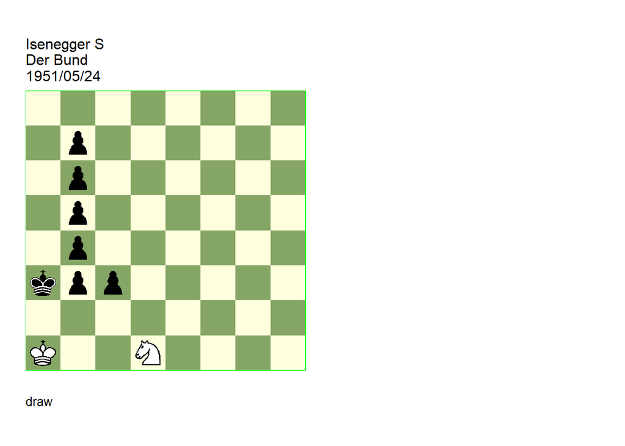

GBR: =0001.06a1a3 -HHdbVI FEN: 8/1p6/1p6/1p6/1p6/kpp5/8/K2N4 w - - 0 1

**1. Nb2!** (1. Ne3? b2+ (1… c2? 2. Nxc2+ bxc2 =) 2. Kb1 Kb3 3. Nc2 Kc4 -+) **1… c2** (1… cxb2+ 2. Kb1 Ka4 3. Kxb2 etc. ) **2. Nc4+ Ka4 3. Nb2+ Ka5 4. Nd3 1/2-1/2**.

### Isenegger =0070.11b2g6 (1951). Cooks, changed solution

Other white bishop moves draw as well in the mainline at move 2. The study can be saved by changing the mainline to **1… Ba5**.

File: Isenegger1951c.pgn

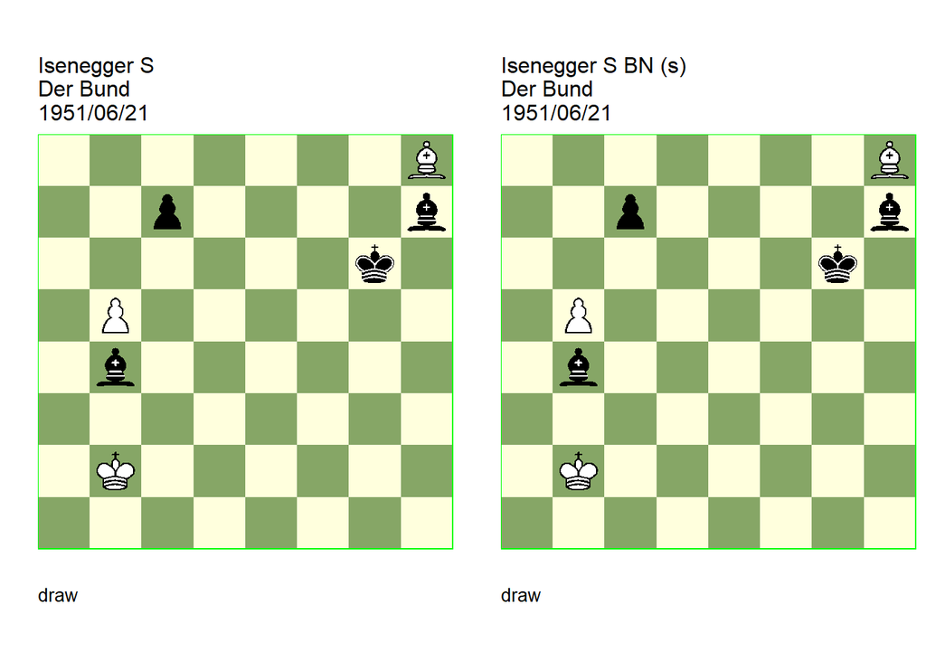

GBR: =0070.11b2g6 U2 -HHdbVI FEN: 7B/2p4b/6k1/1P6/1b6/8/1K6/8 w - - 0 1

U2: Neuenschwander=B 17/10/2025. **1. Bd4 Bd6** (1… Ba5 2. b6! cxb6 (2… Bxb6 3. Bxb6 cxb6 4. Kc3 (4. Kb3 or ) ) 3. Bc3! =) **2. Ba7** (2. b6? c5 3. Be3 c4 4. b7 Bb8 5. Kc3 Bg8) (2. Bg1! (or Bf2/Be3) **cook**s **BN** 2… Bg8 3. b6 c6 4. b7 Bb8 5. Kc3 =) **1/2-1/2**.

GBR: =0070.11b2g6 (s) -HHdbVI FEN: 7B/2p4b/6k1/1P6/1b6/8/1K6/8 w - - 0 1

changed solution: Neuenschwander=B 17/10/2025. **1. Bd4 Ba5** (1… Bd6 2. Ba7 ( 2. b6? c5 3. Be3 c4 4. b7 Bb8 5. Kc3 Bg8) 2… Bg8 3. b6 =) **2. b6! cxb6** ( 2… Bxb6 3. Bxb6 cxb6 4. Kc3 (4. Kb3 or ) ) **3. Bc3! 1/2-1/2**.

# Comments and revisions

## Prize winners

### Kralin +0170.01b6a2 (2000). Cook (VH), correction (BN/VH)

Volker found a cook on move 2 in Kralin’s study. A rotation seems to save the study.

Date: October 27, 2025

File: Kralin2000a.pgn

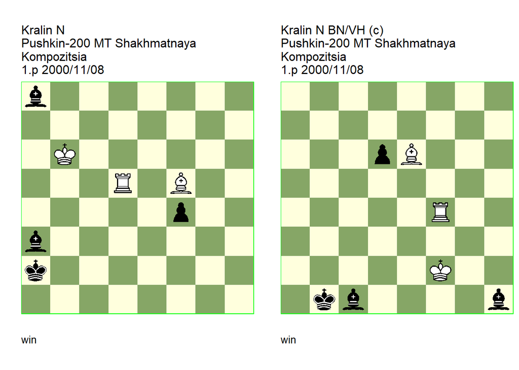

GBR: +0170.01b6a2 (c) U2 FEN: b7/8/1K6/3R1B2/5p2/b7/k7/8 w - - 0 1

Shakhmatnaya Kompozitsia=37 . correction: Kralin=N Shakhmatnaya Nedelya=32(63) 7/2003. U2: Hergert=V 27/10/2025. **1. Rd8! Bh1!** (1… Bf3 2. Rd3 Bh5 (2… Ba8 3. Be6+ Kb2 4. Rb3+ Ka2 5. Rb4+ Ka1 6. Ra4) 3. Be6+ Kb2 4. Rb3+ Ka2 5. Rb5+ ) **2. Rd1!** (2. Kb5? Kb2 3. Rd1 Bb7 4. Rd2+ Kc1 5. Rc2+ Kd1 6. Kb6 Bh1!) ( 2. Kb5! **cook** VH TB DTZ 60 2… Kb2 (2… Bf3 3. Rd2+ Bb2 4. Kb4 Bh5 5. Be6+ Kb1 6. Rh2) 3. Rd2+! Kb3 4. Rd3+ Kb2 5. Kc4) **2… Ba8! 3. Be6+ Kb2 4. Rd2+ Kc3!** (4… Kb1 5. Ra2 f3 6. Rxa3 f2 7. Bh3) **5. Ra2 Kb4 6. Rc2! Ka4!** (6… Bh1 7. Rc4+ Kb3 8. Rxf4+ Kc3 9. Rh4!) (6… f3 7. Rc4+ Kb3 8. Rc8+ Kb2 9. Rxa8 f2 10. Bc4) **7. Rc4+ Bb4 8. Rxf4 Bg2!** (8… Ka3 9. Kb5) **9. Bf7!** (9. Rg4? Bf1!) **9… Ba8 10. Rg4! Bh1!** (10… Bf3 11. Be8+ Kb3 12. Rg3) **11. Be6!** (11. Rg1? Be4!) **11… Ba8 12. Rg7! Ba5+ 13. Kc5! Bb4+** (13… Bh1 14. Ra7) **14. Kc4! 1-0**.

GBR: +0170.01f2b1 (c) FEN: 8/8/3pB3/8/5R2/8/5K2/1kb4b w - - 0 1

correction: Neuenschwander=B Hergert=V 27/10/2025. **1. Rh4! Ba8!** (1… Bc6 2. Bf5+ Kb2 3. Rc4) **2. Ra4!** (2. Ke2 Bc6 3. Rb4+ Bb2 4. Kd2 Be8 = (TB) ) **2… Bh1! 3. Bf5+ Kb2 4. Rb4+ Kc3! 5. Rb1 Kd2 6. Rb3! Kd1! 7. Rd3+ Bd2 8. Rxd6 Bb7 9. Bg6!** (9. Rd7? Ba6) **9… Bh1 10. Rd7 Ba8** (10… Bc6 11. Bh5+) **11. Bf5** (11. Ra7? Bd5) **11… Bh1 12. Rg7 Be1+ 13. Ke3 Bd2+ 14. Kd3 1-0**.

### Fritz +0430.33h1a8 (1951). Cooks(VH)

Volker found cooks on move 1 and 4 in Farago’s second correction.

Date: October 07, 2025

File: Fritz1951a.pgn

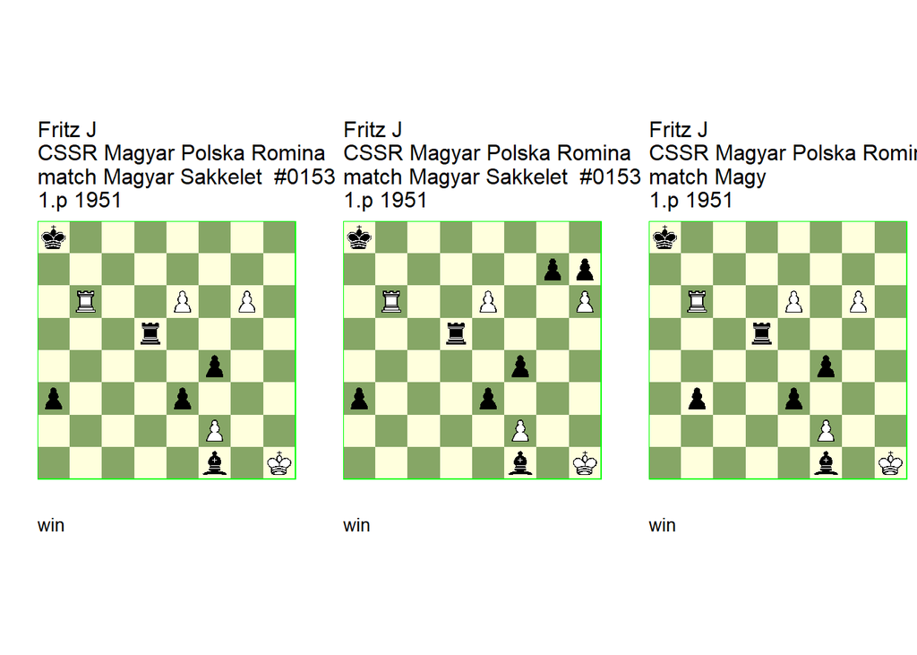

GBR: +0430.33h1a8 U3 FEN: k7/8/1R2P1P1/3r4/5p2/p3p3/5P2/5b1K w - - 0 1

Magyar Sakkelet/5 5.p Bohemian Ring ty 1951-1952. U3: Tikkanen=K New in Chess Magazine=1 2008 U3: Van, der, Heijden=H HHdbVI 17-4-2017. **1. e7!** (1. g7? Rh5+ 2. Kg1 Rg5+ 3. Kxf1 Rxg7) **1… Re5!** (1… Rh5+ 2. Kg1 Rh8 (2… Re5 3. Re6! (3. g7? Bc4 4. Re6 Rg5+ 5. Kh2 Bb5 6. e8=Q+ Bxe8 7. Rxe8+ Kb7 8. g8=Q Rxg8 9. Rxg8 exf2 10. Kg2 a2!) 3… Bb5! (3… Rxe6! **cook** KT 4. g7 a2 5. g8=Q+ Kb7 6. e8=Q Rxe8 7. Qb3+ Kc7 8. Qc3+ Kb7) 4. Rxe5 a2 5. e8=Q+ (5. Rxb5? a1=Q+ 6. Kg2 f3+ 7. Kg3 Qg1+) 5… Bxe8 6. Ra5+ Kb7 7. f3 (7. g7? e2!) 7… Bxg6 8. Rxa2 Bd3 (8… Kc7! **cook** HH ) (8… Kc8! **cook** HH ) 9. Ra4 Kc6 10. Rd4! Bg6 (10… Bb5 11. Rxf4 Bd3 12. Rd4) (10… Be2 11. Kg2 Kc5 12. Rxf4 Bd3 13. Rf8 Kd4 14. Rd8+ Kc3 15. f4 Kd2 (15… Be4+ 16. Kf1 Bd3+ 17. Ke1) 16. Re8! e2 17. Kf2 Bb5 18. Re5! Bd3 19. Re3!) 11. Kf1! Kc5 12. Rxf4 Bd3+ 13. Ke1 Kd5 14. Ra4 Ke5 (14… Bc4 15. f4 Bd3 16. Ra5+ Ke4 (16… Ke6 17. Re5+) (16… Kd6 17. Ra3) 17. f5) (14… e2 15. Ra3 Bc4 16. Re3) 15. Ra3 Kd4 16. Ra5! Bg6 (16… e2 17. Kd2) 17. Ra4+ Kd3 (17… Ke5 18. Ke2) 18. Ra3+ Kd4 19. Ke2 Ke5 20. Kxe3) 3. Kxf1 e2+ 4. Kxe2 Re8 5. Ra6+ Kb7 6. Rxa3 Rxe7+ 7. Kf3 Rg7 8. Kxf4 Rxg6 9. Rc3) **2. g7!** (2. Re6? Rxe6 3. g7 Rxe7 4. g8=Q+ Ka7 5. Qa2 Ba6 6. Qxa3 exf2 7. Qxe7+ Bb7+) **2… Bc4! 3. Re6! Bd5+** ( 3… Rh5+ 4. Kg2 Rg5+ 5. Kf3 Bb5 6. e8=Q+ Bxe8 7. Rxe8+ Kb7 8. g8=Q Rxg8 9. Rxg8) (3… Rxe6 4. g8=Q+) (3… Bxe6 4. e8=Q+) **4. f3!** (4. Kg1? Rg5+ 5. Kf1 Bc4+ 6. Ke1 Rg1#) **4… Bxf3+ 5. Kg1! Rg5+ 6. Kf1! Bh5! 7. Rg6! Rxg6** (7… Bxg6 **main** 8. g8=Q+) **8. e8=Q+ 1-0**.

GBR: +0430.35h1a8 (c) U3 FEN: k7/6pp/1R2P2P/3r4/5p2/p3p3/5P2/5b1K w - - 0 1

Magyar Sakkelet/5 . correction: Farago=P FIDE revue=1 1-3/1963. U3: Farago=P Revista de Romana de Sah=4 4/1964. **1. e7 Re5** (1… Rh5+ 2. Kg1 Re5 3. Re6! ( 3. hxg7? Bc4 4. Re6 Rg5+ 5. Kh2 Bb5 6. e8=Q+ Bxe8 7. Rxe8+ Kb7 8. g8=Q Rxg8 9. Rxg8 exf2 10. Kg2 a2) 3… Bb5 (3… Rxe6 4. hxg7 Rxe7 (4… a2! **cook** PF 5. g8=Q+ Kb7 6. e8=Q Rxe8 7. Qb3+ Kc7 8. Qc3+ Kb7) 5. g8=Q+ Kb7 6. Kxf1 exf2 7. Qf8 Rc7 8. Qxa3) 4. Rxe5 (4. e8=Q+? Bxe8 5. Rxe5 gxh6 6. Rxe8+ Kb7 7. Re4 a2) 4… a2 5. Rxb5 a1=Q+ 6. Kh2) (1… Ka7 2. Rb4 Re5 3. hxg7 a2 4. Ra4+) **2. hxg7** (2. Re6? Rh5+ 3. Kg1 Bb5) **2… Bc4 3. Re6! Bd5+** (3… Bxe6 **main** 4. e8=Q+) (3… Rxe6 **main** 4. g8=Q+) (3… Rh5+ 4. Kg2! Rg5+ 5. Kf3! Bb5 (5… Bd5+ 6. Kxf4) 6. e8=Q+ Bxe8 7. Rxe8+ Kb7 8. g8=Q Rxg8 9. Rxg8 exf2 10. Kxf2) **4. f3!** (4. Kg1? Rg5+ 5. Kf1 Bc4+ 6. Ke1 Rg1#) **4… Bxf3+ 5. Kg1! Rg5+ 6. Kf1 Bh5 7. Rg6! Rxg6** (7… Bxg6 **main** ) **8. e8=Q+ 1-0**.

GBR: +0430.33h1a8 (c) U3 FEN: k7/8/1R2P1P1/3r4/5p2/1p2p3/5P2/5b1K w - - 0 1

Magyar Sakkelet/4 5.p Bohemian Ring ty 1951-1952. correction: Farago=P Revista de Romana de Sah=12 12/1964. U3: Hergert=V beatochess 07/10/2025. **1. e7 Rh5+** ( 1… Re5! **cook** VH 2. g7 Bc4 3. Re6 Bd5+ 4. f3! Rh5+ (4… Bxf3+? 5. Kg1 Rg5+ 6. Kf1 Bh5 7. Rg6 =) 5. Kg2 Rg5+ 6. Kh3 Bxe6+ 7. Kh4 Rxg7 8. e8=Q+ Ka7) **2. Kg1 Re5 3. Re6!** (3. g7? Bc4 4. Re6 Rg5+ 5. Kh2 Bb5 6. e8=Q+ Bxe8 7. Rxe8+ Kb7! 8. g8=Q Rxg8 9. Rxg8 exf2 10. Kg2 b2) (3. Kxf1? Rxe7 4. Rxb3 Re6!) **3… Rxe6** (3… Bb5 4. Rxe5 Be8 5. g7 b2 6. g8=Q b1=Q+ 7. Kh2 Kb7 8. Qxe8) **4. g7 b2** (4… Rxe7! **cook** VH 5. g8=Q+ Ka7 6. Qxb3 Ba6!1) **5. g8=Q+ Ka7 6. Qf7 b1=Q 7. e8=Q+ Qb7 8. Qxb7+ Kxb7 9. Qxe6 e2 10. f3 1-0**.

### Mandler +0400.55e4e8 (1957). Not cooked (VH)

The study is correct.

Date: October 07, 2025

File: Mandler1957a.pgn

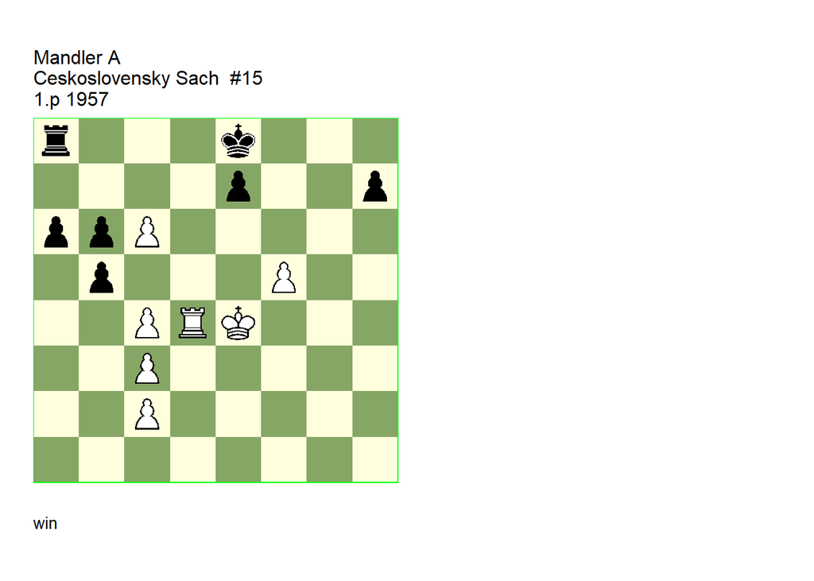

GBR: +0400.55e4e8 FEN: r3k3/4p2p/ppP5/1p3P2/2PRK3/2P5/2P5/8 w q - 0 1

Ceskoslovensky Sach/10 1.p Bohemian Ring ty 1957-1959. U3: Hornecker=S HHdbIV#29135 26-4-2006. Comment: Hergert=V beatochess 07/10/2025. **1. f6** (1. Rd7? Rc8 2. Kd5 Rd8) **1… exf6 2. c5!** (2. Kd5? O-O-O+! 3. Ke6 Kc7) **2… bxc5 3. Rd7 Rc8** (3… a5 4. Rc7 a4 5. Kd5 a3 6. Rxh7 O-O-O+ 7. Kxc5) (3… h5! **cook** NH no! VH 4. Rh7 (4. Rc7! h4 5. Kd5 Rd8+ 6. Kxc5 Rd2 7. Rh7 Rxc2 8. c7 Rxc3+ 9. Kd6 b4 10. Rh8+ Kf7 11. Rxh4 b3 12. Rh7+ Kg6 13. Rh3 Rxh3 14. c8=Q +- TB ) 4… O-O-O) **4. Rb7 Rxc6 5. Kd5 Rc8 6. Rxh7 1-0**.

### Sochnev +0041.13h3h1 (1986). Cook (VH)

**7. Nh3** cooks the study.

Date: October 07, 2025

File: Sochnev1986a.pgn

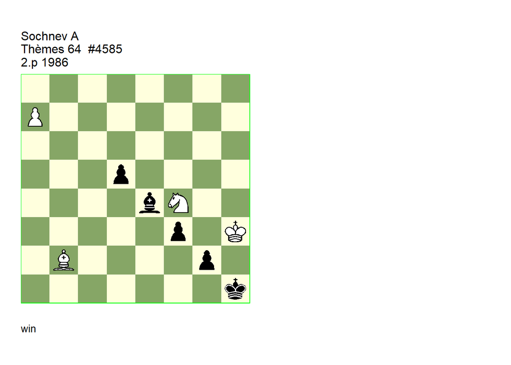

GBR: +0041.13h3h1 U2 FEN: 8/P7/8/3p4/4bN2/5p1K/1B4p1/7k w - - 0 1

Themes 64=122 Themes 64/4-6. U2: Hergert=V 07/10/2025. **1. Bd4 f2! 2. Bxf2 d4 3. Ne2** (3. Bxd4? g1=Q) **3… g1=Q! 4. Bxg1** (4. Nxg1? d3 5. Be3 d2!) **4… Bg2+** (4… d3 5. Ng3+ Kxg1 6. Nxe4) **5. Kg3 d3 6. Nf4! d2** (6… Be4 7. Be3) **7. Nxg2** (7. Nh3! **cook** VH 7… d1=Q 8. Nf2+ Kxg1 9. Nxd1 +-) **7… d1=Q 8. a8=Q Qa1!** (8… Kxg1 9. Qa7+ Kh1 10. Qh7+ Kg1 11. Qh2+ Kf1 12. Ne3+) (8… Qd6+ 9. Nf4+) **9. Qc6!** (9. Qxa1?) (9. Qb7? Qa7!) (9. Ba7? Qxa7! 10. Qxa7) **9… Qc1** (9… Qg7+ 10. Kh3 Kxg1 11. Qc1+) **10. Qe4! Kxg1 11. Qd4+ Kh1 12. Qh4+ Kg1 13. Qh2+ Kf1 14. Qh1+ 1-0**.

### Koranyi +0414.02e2h2 (1966). Comment (VH/BH)

**2. Kf3** also wins but wastes time.

Date: October 07, 2025

File: Koranyi1966a.pgn

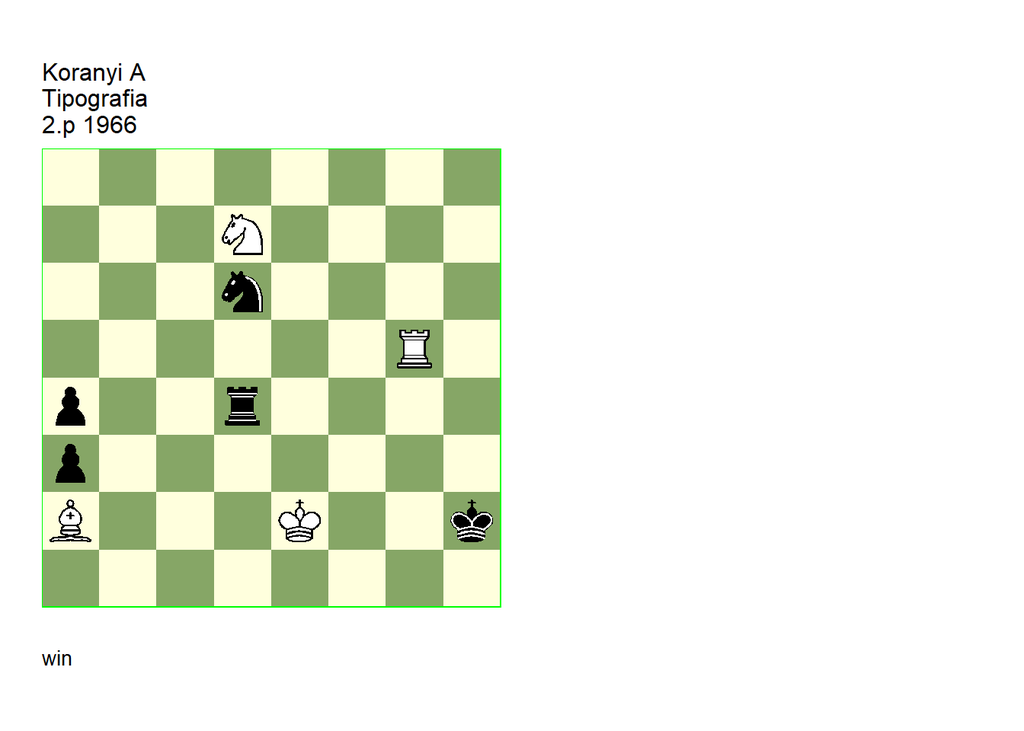

GBR: +0414.02e2h2 FEN: 8/3N4/3n4/6R1/p2r4/p7/B3K2k/8 w - - 0 1

(EG#00461). Comment: Hergert=V, Neuenschwander=B beatochess 30/10/2025. **1. Ne5!** (1. Bd5? a2 2. Bxa2 Rd2+!) (1. Ke3? Nf5+! 2. Rxf5 Rxd7) **1… Rd2+! 2. Ke3** (2. Kf3 comment VH/ **BN** 2… Rf2+! 3. Ke3 Rxa2 leads to the **main** line ) **2… Rxa2 3. Nf3+ Kh3 4. Kf4 Nf5! 5. Rh5+** (5. Rxf5? Kg2 6. Rh5 Rf2) **5… Nh4! 6. Rxh4+ Kg2 7. Rh2+ Kf1 8. Nd2+** (8. Rxa2?) **8… Ke1** (8… Kg1 9. Kg3 Rb2 10. Rg2+ Kh1 11. Re2) **9. Ke3 Kd1 10. Kd3 Ke1 11. Re2+!** (11. Nf3+? Kf1 12. Rxa2) **11… Kd1 12. Rf2! Kc1 13. Rf1+ Kb2 14. Rb1# 1-0**.

## Misc

### Perelman +0170.00b6c8 (1930). Correction (VH)

Volker Hergert corrected the study.

Date: October 20, 2025

File: Perelman1930a.pgn

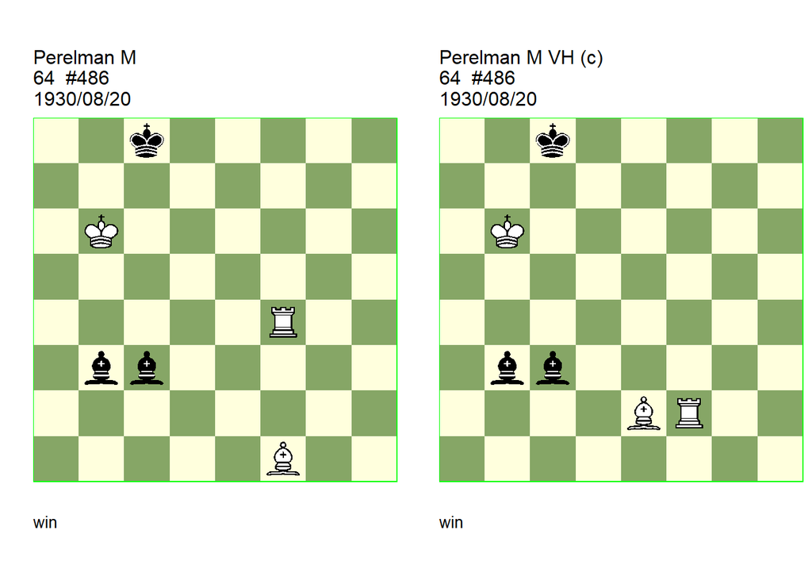

GBR: +0170.00b6c8 U1 FEN: 2k5/8/1K6/8/5R2/1bb5/8/5B2 w - - 0 1

64=22-23 . U1: Garcia=M HHdbIV#13846 19-1-2007. **1. Rf8+!** (1. Bb5! **cook** MG 1… Bg7 2. Re4 Bf7 3. Re7 Bd4+ 4. Kc6 Bh5 5. Be2) **1… Kd7 2. Rf3 Bd4+ 3. Ka5! Bc2 4. Bd3! Bd1** (4… Bxd3 5. Rxd3) **5. Bb5+ Kc7 6. Rd3 Bb6+ 7. Ka6 Be2 8. Rc3+ 1-0**.

GBR: +0170.00b6c8 (c) FEN: 2k5/8/1K6/8/8/1bb5/4BR2/8 w - - 0 1

correction: Hergert=V 22/10/2025. **1. Rf8+ Kd7 2. Rf3 Bd4+ 3. Ka5 Bc2 4. Bd3 Bd1 5. Bb5+ Kc7 6. Rd3 Bb6+ 7. Ka6 Be2 8. Rc3+ 1-0**.

### Gurgenidze =0304.21h4a6 (1974). Cook (VH)

**4. Kh6** cooks the study.

Date: October 07, 2025

File: Gurgenidze1974a.pgn

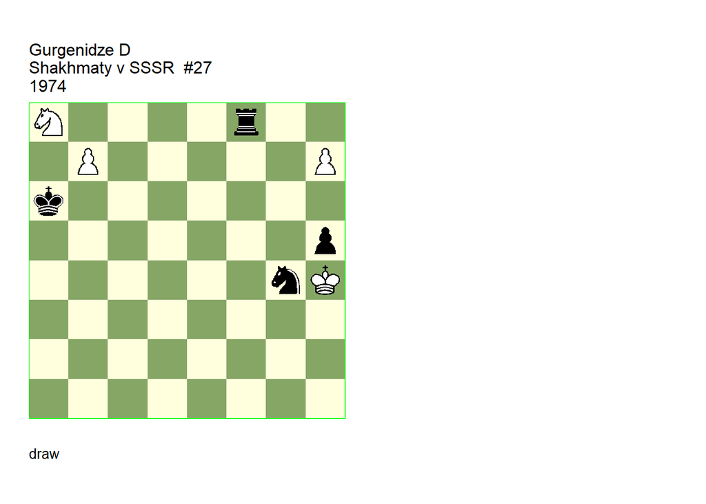

GBR: =0304.21h4a6 U2 FEN: N4r2/1P5P/k7/7p/6nK/8/8/8 w - - 0 1

Shakhmaty v SSSR/7. U2: Hergert=V beatochess 07/10.2025. **1. Nc7+!** (1. Kxh5? Nf6+ 2. Kg6 Nxh7 3. Nc7+ Kxb7 4. Ne6 Rf6+) **1… Ka7! 2. Ne6 Rh8 3. Kxh5 Nf6+ 4. Kg6!** (4. Kh6! **cook** VH 4… Nxh7 (4… Rxh7+ 5. Kg6!1) 5. Kg6 Re8 6. Nd4! (6. Ng7? Nf8+ -+) 6… Kxb7 (6… Nf8+ 7. Kf7!1) 7. Kxh7!1 ) **4… Nxh7 5. Kh6!** (5. Kg7? Re8 6. Kf7 Rb8! 7. Kg7 Rxb7+) **5… Re8 6. Ng7 Rh8 7. Ne6 Kxb7 8. Kg7 Re8 9. Kf7 Rc8 10. Kg7 Re8** (10… Rc6 11. Nd8+) **11. Kf7 Ra8 12. Kg7 Re8** (12… Ra6 13. Nc5+) **13. Kf7 1/2-1/2**.

### Hlinka =0130.32c5c2 (1987). Additional cooks (VH)

Volker found more deficiencies in Hlinka’s study.

Date: October 07, 2025

File: Hlinka1987a.pgn

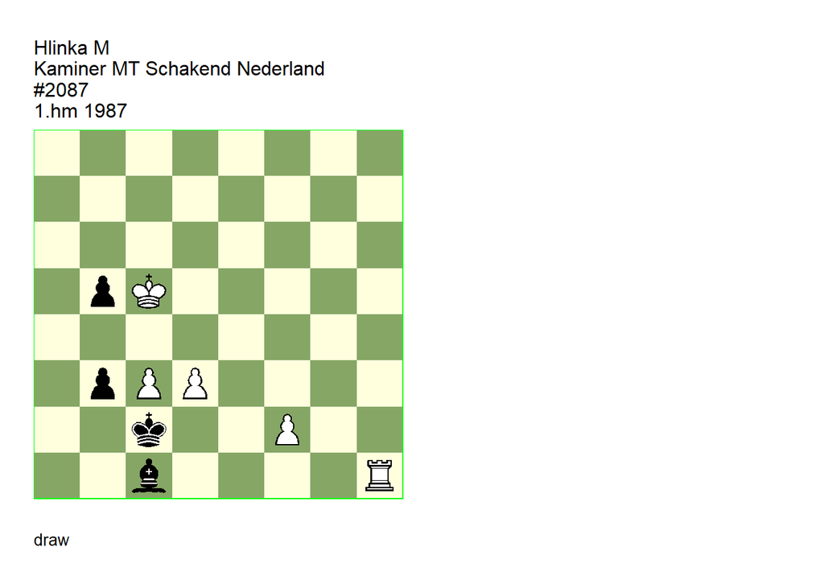

GBR: =0130.32c5c2 U2 U3 FEN: 8/8/8/1pK5/8/1pPP4/2k2P2/2b4R w - - 0 1

Schakend Nederland/4 (EG#07477). U3: Staudte=R HHdbII#49185 1-11-1996 U3: Bourzutschky=M HHdbV#26043 28-12-2010 U3: Hergert=V beatochess 07/10/2025. **1. f4** (1. Rh4? b4! 2. Rxb4 Ba3) **1… b2** (1… Bxf4 2. Kxb5) **2. Rh2+ Bd2 3. Rh1 Kxc3! 4. d4** (4. Rb1? b4 5. f5 Kc2 6. Rxb2+ Kxb2 7. f6 b3 8. f7 Bh6) **4… b4 5. d5!** (5. f5? Be3! (5… Bc1 6. Rh3+ Kc2 7. Rh2+ Kb3 8. Rxb2+ Bxb2 9. f6 ) 6. Kb5 (6. Rf1 **cook** MB 6… Bxd4+ 7. Kd5 Be3! (7… Bf6? 8. Rf3+ Kc2 9. Kc4) 8. f6 Bh6 9. f7 Bf8 10. Rg1 Kc2 -+ VH, no **cook** ) 6… Bc1 7. Rh3+ Kc2 8. Rh2+ Bd2 9. Rh1 b1=Q 10. Rxb1 Kxb1 11. f6 b3 12. d5 b2 13. d6 Kc2 14. d7 b1=Q+) **5… Bc1** (5… Be3+! **cook** VH 6. Kb5 (6. Kc6 Bc1 -+ the white king can move to the fourth rank. ) 6… Bc1 7. Rh3+ Kc2! (7… Kd4? 8. Rb3!1) 8. d6 b1=Q 9. d7 Bd2! -+ VH ) **6. Rh3+ Kc2 7. d6!** (7. Rh2+? Kb3 8. Rxb2+ Bxb2) **7… b1=Q 8. d7 Be3+! 9. Rxe3 Qd1 10. Kc6 b3! 11. Kc7** ( 11. Re6? Qf3+ 12. Kb6 b2! 13. Rc6+ Kb3 14. d8=Q b1=Q) (11. Re5? Qf3+ 12. Kb6 Qd3! 13. Rc5+ Kd2) **11… b2** (11… Qc1 -+ **cook** VH ) **12. Re6!** (12. Re5? Qd3! 13. d8=Q Qxd8+ 14. Kxd8 b1=Q 15. f5 Qb8+) **12… Qxd7+!** (12… b1=Q 13. Rc6+!) **13. Kxd7 b1=Q 14. f5! Qb5+ 15. Rc6+ Kd3 16. f6 Ke4** (16… Qb7+! **cook** RS 17. Rc7 Qd5+ 18. Kc8 Qg8+ 19. Kb7 Qd8 20. f7 Kd4 21. Kc6 Ke5 22. Rd7 Qa8+ 23. Kb5 Ke6 24. Rc7 Kd6) **17. f7 Qd5+ 18. Ke7! Qxc6 19. f8=Q 1/2-1/2**.

### Olimpiev +0143.01a5c7 (1974). Additional cook (VH)

The mainline does not work.

Date: October 07, 2025

File: Olimpiev1974a.pgn

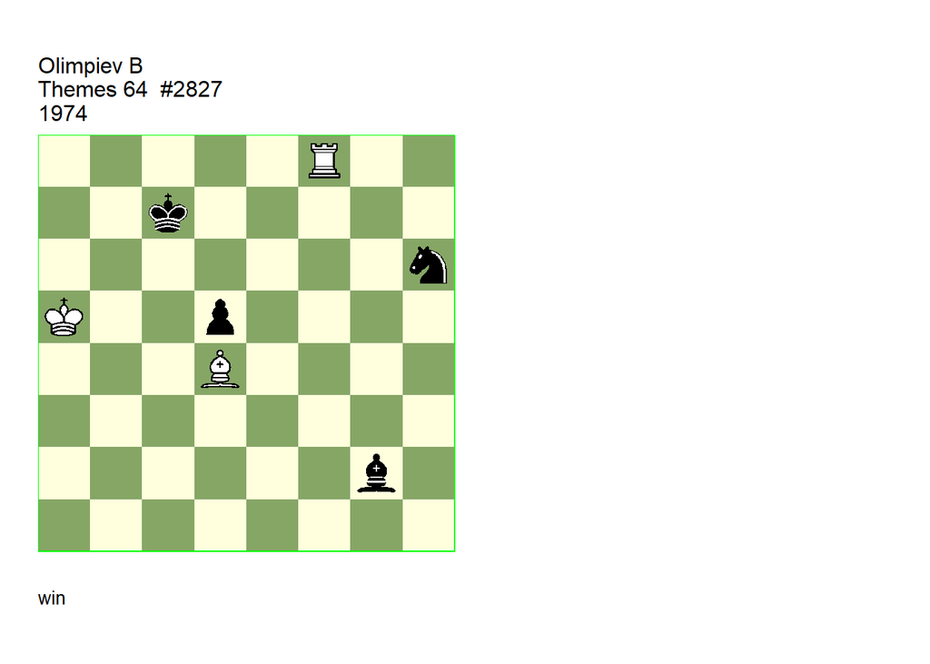

GBR: +0143.01a5c7 U2 U3 FEN: 5R2/2k5/7n/K2p4/3B4/8/6b1/8 w - - 0 1

Themes 64=76 Themes 64/10-12. U2: Perkonoja=P Themes 64=79 7-9/1975. U3: Hergert=V beatochess 07/10/2025. **1. Rf6!** (1. Bg7? Ng4 2. Rf4 Ne3) (1. Rf2? Be4) **1… Ng4!** (1… Ng8 2. Rf7+ Kd6! 3. Rg7 Ne7 4. Kb6! (4. Kb5? Bf1+) 4… Nc8+ (4… Nf5 5. Bc5+) 5. Kb7) **2. Rf4!** (2. Rf7+? Kd6! 3. Rf4 Nh2! (3… Ne5? 4. Rf6+) 4. Rf2 Nf3! 5. Ba7 Bh1 6. Rf1 Bg2 7. Rf2 Bh1) **2… Nh6!** (2… Nh2 3. Rf2 Nf3 4. Bb6+) **3. Bg7 Ng8 4. Rf7+** (4. Be5+? Kd7! 5. Rg4 Ne7! 6. Rxg2 (6. Rg7 Ke6) 6… Nc6+) (4. Rg4! **cook** PP 4… Be4 5. Be5+) **4… Kc6** (4… Kd6 5. Bf8+ Ke6 6. Rg7) (4… Kd8! **cook** VH ) **5. Be5! d4 6. Rg7! Bd5 7. Rc7# 1-0**.

### Rusinek =0317.10g2a8 (1974). Additional cook (VH)

The mainline does not work due to **5… Nc3**.

Date: October 07, 2025

File: Rusinek1974a.pgn

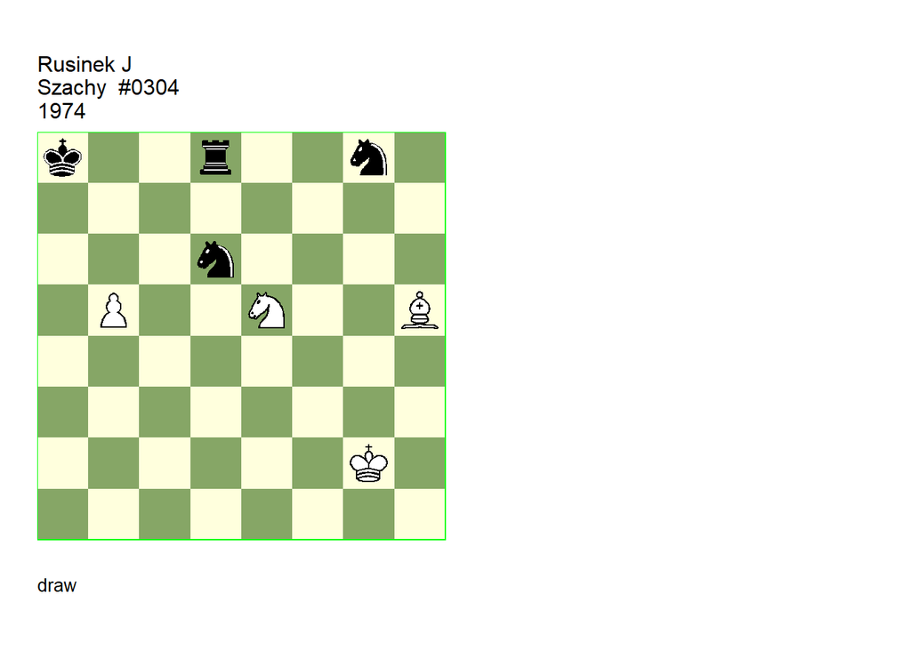

GBR: =0317.10g2a8 U2 U3 FEN: k2r2n1/8/3n4/1P2N2B/8/8/6K1/8 w - - 0 1

Szachy=8(332) Szachy/8. U2: Garcia=M HHdbV#41503 23-9-2011. U3: Hergert=V beatochess 07/10/2025. **1. Bf3+ Nb7 2. Nc6 Rd2+ 3. Kg1!** (3. Kf1 Nf6 4. Na5 Nd5 5. Nc6 (5. Nc4! **cook** MG ) 5… Ne3+ 6. Ke1 Rd3 7. Na5 Nd5!) **3… Nf6 4. Na5 Nd5 5. Nc6!** (5. Nc4! **cook** MG ) **5… Rd3** (5… Nc3! **cook** VH 6. Na5 Ka7 7. Nxb7 Kb6 8. Kf1 Nxb5 9. Ke1 Rh2 10. Nd8 Nd4 11. Bd1 Rh7 -+) **6. Kf2** (6. Bh1? Nf6! 7. Na5 Rd1+ 8. Kh2 Ng4+) **6… Nf6 7. Na5 Ng4+! 8. Kg2! Ne3+ 9. Kf2 Nd5 10. Nc6!** (10. Nc4!1 VH ) **10… Nf4 11. Na5 Nh3+ 12. Kg2!** (12. Ke2? Ra3!) **12… Nf4+ 13. Kf2 Nd5 14. Nc6** (14. Nc4!1 VH ) **1/2-1/2**.